# Quality Assessment For Weight Lifting Exercises

*Auscitte*

## Introduction

In the course of human activity recognition study a group of researchers from Lancaster University in collaboration with Pontifical Catholic University of Rio de Janeiro [1] collected sensor measurements taken while participants were performing biceps curls. Sensors used during the experiment included accelerator, gyroscope, magnetometer; in addition to raw readings roll, pitch, and yaw were calculated and recorded. Whether the exercise is performed correctly or not was determined visually and the observations were divided into 5 classes (“A”, “B”, “C”, “D”, and “E”) according to the type of error participant made (e.g., wrong posture, insufficient range of motion) with “A” denoting the correct form. The data constitute input data set for our project. The present work aims to construct a model allowing to predict how well the exercise was performed based on the sensor measurements using out-of-the-box machine learning algorithm of our choosing.

## Cleaning Data

We begin by loading data set and converting all the variables containing sensor measurements and their derivatives to the numeric format (the code doing so is omitted). In order to ensure the correct operation of learning algorithm it is necessary to remove records with missing data from the data set. We remove the variable completely if the number of NA values exceeds 40%. Since in our case variable values either are fully specified or contain more than 90% of NANs, no further processing is necessary.

```r
RemoveNAs <- function(data) {

  vc <- integer(0) #indecies of variables that are to be kept
  nanprc <- numeric(0)
  for (c in seq(dim(data)[2]))
  {
    col <- data[, c]

    lenNA <- length(col[is.na(col)])

    if ((lenNA * 100.0 / dim(data)[1]) < 40.0)
              vc <- c(vc, c)

    nanprc <- c(nanprc, (lenNA * 100.0 / dim(data)[1])) #percentage of NAs
  }

  data <- data[, vc] #remove variables

  #diagnostic output
  if (length(nanprc[nanprc > 0 & nanprc < 40.0]) == 0)
      print("All the NAs have been removed")

  data
}
```

It should be noted, that values for some variables seem to be recorded only at the start of a sliding window, i.e. when variable *new_window* is equal to “yes”. Below is the list of such variables.

```
##  [1] "max_roll_belt"            "max_picth_belt"           "min_roll_belt"            "min_pitch_belt"
##  [5] "amplitude_roll_belt"      "amplitude_pitch_belt"     "var_total_accel_belt"     "avg_roll_belt"
##  [9] "stddev_roll_belt"         "var_roll_belt"            "avg_pitch_belt"           "stddev_pitch_belt"
## [13] "var_pitch_belt"           "avg_yaw_belt"             "stddev_yaw_belt"          "var_yaw_belt"
## [17] "var_accel_arm"            "avg_roll_arm"             "stddev_roll_arm"          "var_roll_arm"
## [21] "avg_pitch_arm"            "stddev_pitch_arm"         "var_pitch_arm"            "avg_yaw_arm"
## [25] "stddev_yaw_arm"           "var_yaw_arm"              "max_roll_arm"             "max_picth_arm"
## [29] "max_yaw_arm"              "min_roll_arm"             "min_pitch_arm"            "min_yaw_arm"
## [33] "amplitude_roll_arm"       "amplitude_pitch_arm"      "amplitude_yaw_arm"        "max_roll_dumbbell"
## [37] "max_picth_dumbbell"       "min_roll_dumbbell"        "min_pitch_dumbbell"       "amplitude_roll_dumbbell"
## [41] "amplitude_pitch_dumbbell" "var_accel_dumbbell"       "avg_roll_dumbbell"        "stddev_roll_dumbbell"
## [45] "var_roll_dumbbell"        "avg_pitch_dumbbell"       "stddev_pitch_dumbbell"    "var_pitch_dumbbell"
## [49] "avg_yaw_dumbbell"         "stddev_yaw_dumbbell"      "var_yaw_dumbbell"         "max_roll_forearm"
## [53] "max_picth_forearm"        "min_roll_forearm"         "min_pitch_forearm"        "amplitude_roll_forearm"
## [57] "amplitude_pitch_forearm"  "var_accel_forearm"        "avg_roll_forearm"         "stddev_roll_forearm"
## [61] "var_roll_forearm"         "avg_pitch_forearm"        "stddev_pitch_forearm"     "var_pitch_forearm"
## [65] "avg_yaw_forearm"          "stddev_yaw_forearm"       "var_yaw_forearm"
```

Thus, we could potentially populate variable vectors by simply copying the values. However, as as we will demonstrate in the following it is possible to successfully predict outcome without introducing these variables into the model, therefore, for the sake of simplicity we adhere to the original idea and *RemoveNAs()* function is used to clean the data.

```
## [1] "All the NAs have been removed"
```

In order to identify outliers a series of boxplot plots which we inspected visually was used. See an example of such plot below. Plots for the entire data can be obtained by downloading ExploratoryOutliers.pdf for original data and ExploratoryClean.pdf for data with “clear” outliers removed.

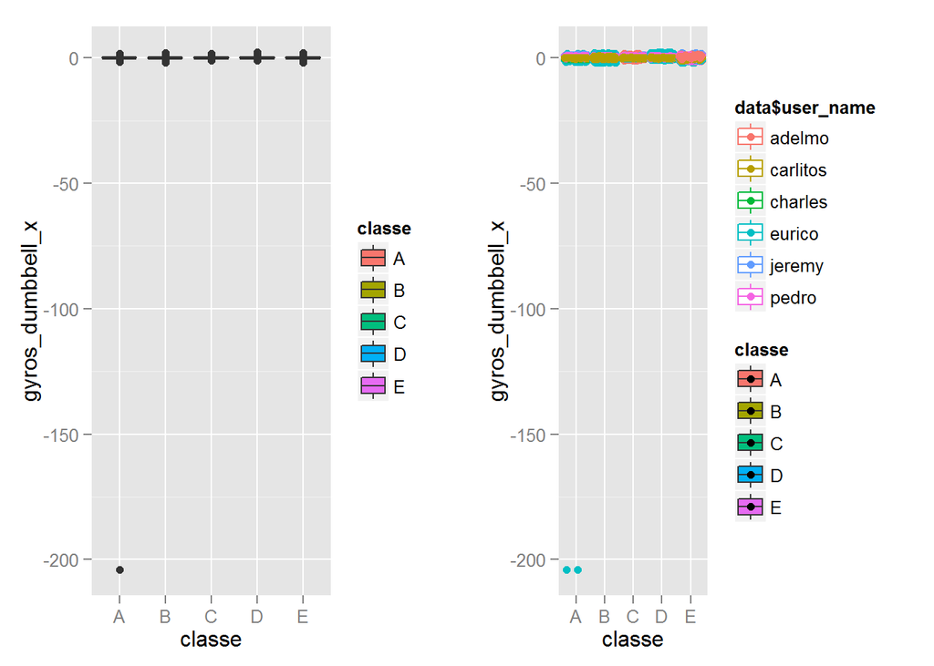

## Preprocessing And Exploratory Data Analysis

Exploratory data analysis did not contribute significantly to our understanding of dependencies and interactions between variables. A series of boxplots, for example, demonstrate strong dependency of measurements on the *user_name* variable rather than *classe* which we would like to avoid since our goal is to give accurate predictions irrespective of the sportsman physical characteristics.

In addition, We checked if the data contained variables with near-zero variance which were unlikely to serve as predictors.

```r
nz <- nearZeroVar(data[, 8:dim(data)[2]], saveMetrics = TRUE)
if (!(TRUE %in% nz$nzv))
  print("No variables with near-zero variance found")
```

```
## [1] "No variables with near-zero variance found"
```

Taking into account results of exploratory analysis, we decided to dispose of irrelevant data, that is, data not derived from sensors measurements and build the model based on the rest of variables.

```r
data <- data[, -c(1, 2, 3, 4, 5, 6, 7)]
```

## Model Fitting

Due to the fact that computational resources available to us were limited the “random forest” learning algorithm provided a suitable compromise between accuracy and running time. Parameters for the learning algorithm and resampling procedure were set based on a number of experiments.

We start by partitioning the data into training set and a data used for validation.

```r
inTrain <- createDataPartition(y = data$classe, p = 0.60, list = FALSE)
training <- data[inTrain, ]
testing <- data[-inTrain, ]
```

Next, the resampling method is chosen. We perform cross-validation with the number of folds equal to 3 which constitutes a sufficient tradeoff between speed and accuracy.

```r
ctrl <- trainControl(method = "cv", number = 3, repeats = 1, verboseIter = FALSE)
```

The typical values for number of trees to grow are 10, 30, or 50; we select the medium one. Random forests algorithm does not require data prepossessing such as normalization of principal component analysis, therefore, we do not initialize *preProcess* parameter. Finally, *tuneLength* allows to specify how many different sets of parameters will be generated by caret. We set this value equal to the number of folds cross-validation uses.

```r
print(
  system.time(
    modFit <- train(classe ~ ., method = "rf", ntree = 30, trControl = ctrl,
                    data = training, tuneLength = 3)))
```

```
##    user  system elapsed
##  220.82    0.53  225.01
```

```r
prtrain <- predict(modFit, newdata = training)
cmtr <- confusionMatrix(prtrain, training$classe)
print(paste("Accuracy is equal to ", cmtr$overall[1]))
```

```
## [1] "Accuracy is equal to  0.999830148619958"
```

Now that the training phase is over the resulting model is evaluated.

In addition to cross-validation, we will validate the model on the *testing* data set, which is used once only for model evaluation purposes.

```r
prtest <- predict(modFit, newdata = testing)
cmtst <- confusionMatrix(prtest, testing$classe)
print(paste0("Accuracy is equal to ", cmtst$overall[1], ", out-of-sample error is ", 1 - cmtst$overall[1]))
```

```
## [1] "Accuracy is equal to 0.993371574251115, out-of-sample error is 0.00662842574888467"
```

Out-of-sample error provides an estimate of model accuracy. Later appears to be sufficiently high to accept the model. It is ready to be applied. As an example of “real-life” application, we present the results of running the prediction algorithm on the evaluation data supplied as part of the assignment.

```
## Confusion Matrix and Statistics
##
##           Reference
## Prediction A B C D E
##          A 7 0 0 0 0
##          B 0 8 0 0 0
##          C 0 0 1 0 0
##          D 0 0 0 1 0
##          E 0 0 0 0 3
##
## Overall Statistics
##
##                Accuracy : 1
##                  95% CI : (0.8316, 1)
##     No Information Rate : 0.4
##     P-Value [Acc > NIR] : 1.1e-08
##
##                   Kappa : 1
##  Mcnemar's Test P-Value : NA
##
## Statistics by Class:
##
##                      Class: A Class: B Class: C Class: D Class: E
## Sensitivity              1.00      1.0     1.00     1.00     1.00
## Specificity              1.00      1.0     1.00     1.00     1.00
## Pos Pred Value           1.00      1.0     1.00     1.00     1.00
## Neg Pred Value           1.00      1.0     1.00     1.00     1.00
## Prevalence               0.35      0.4     0.05     0.05     0.15
## Detection Rate           0.35      0.4     0.05     0.05     0.15
## Detection Prevalence     0.35      0.4     0.05     0.05     0.15
## Balanced Accuracy        1.00      1.0     1.00     1.00     1.00
```

The algorithms was able to identify all 20 classes correctly.

Finally, in order to lay grounds for the further project development we will identify which variables are actually used for outcome prediction.

```
## rf variable importance
##
##   only 20 most important variables shown (out of 52)
##
##                      Overall
## roll_belt             100.00
## yaw_belt               60.49
## pitch_forearm          60.30
## pitch_belt             52.08
## magnet_dumbbell_y      48.44
## magnet_dumbbell_z      44.67
## roll_forearm           42.77
## accel_belt_z           23.78
## magnet_dumbbell_x      23.15
## roll_dumbbell          21.36
## accel_dumbbell_z       17.92
## accel_dumbbell_y       17.79
## accel_forearm_x        17.48
## total_accel_dumbbell   16.96
## magnet_belt_z          15.81
## gyros_belt_z           15.67
## magnet_forearm_z       12.78
## yaw_arm                12.76
## magnet_belt_x          11.59
## yaw_dumbbell           10.41
```

## Conclusion

Using random forests learning algorithm we constructed a model which was able to predict whether the exercise was performed correctly on evaluation data with 100% accuracy. Although the project may be considered successful, the fact that variable importance varies significantly suggests that a simpler model could be built.

## References

[1] Vellosso, E., Bulling, A., Gellersen, H., Ugulino, W., Fulks, H. Qualitative Activity Recognition of Weight Listing Exercises, Proceedings pf 4th Internationlal Conference in Cooperation with SIGCHI (Augmented Human ’13). Stuttgart, Germany: ACM SIGCHI, 2013